# tranda

part1

```python
import pandas as pd
import numpy as np
import matplotlib.pyplot as plt
import seaborn as sns
```

```python
df=pd.read_csv("shopping_trends.csv")
```

part2

```python
df.shape
```

```
(3900, 19)
```

```python
df.head(10)
```

|  | Customer ID | Age | Gender | Item Purchased | Category | Purchase Amount (USD) | Location | Size | Color | Season | Review Rating | Subscription Status | Payment Method | Shipping Type | Discount Applied | Promo Code Used | Previous Purchases | Preferred Payment Method | Frequency of Purchases |
| --- | --- | --- | --- | --- | --- | --- | --- | --- | --- | --- | --- | --- | --- | --- | --- | --- | --- | --- | --- |
| 0 | 1 | 55 | Male | Blouse | Clothing | 53 | Kentucky | L | Gray | Winter | 3.1 | Yes | Credit Card | Express | Yes | Yes | 14 | Venmo | Fortnightly |
| 1 | 2 | 19 | Male | Sweater | Clothing | 64 | Maine | L | Maroon | Winter | 3.1 | Yes | Bank Transfer | Express | Yes | Yes | 2 | Cash | Fortnightly |
| 2 | 3 | 50 | Male | Jeans | Clothing | 73 | Massachusetts | S | Maroon | Spring | 3.1 | Yes | Cash | Free Shipping | Yes | Yes | 23 | Credit Card | Weekly |
| 3 | 4 | 21 | Male | Sandals | Footwear | 90 | Rhode Island | M | Maroon | Spring | 3.5 | Yes | PayPal | Next Day Air | Yes | Yes | 49 | PayPal | Weekly |
| 4 | 5 | 45 | Male | Blouse | Clothing | 49 | Oregon | M | Turquoise | Spring | 2.7 | Yes | Cash | Free Shipping | Yes | Yes | 31 | PayPal | Annually |
| 5 | 6 | 46 | Male | Sneakers | Footwear | 20 | Wyoming | M | White | Summer | 2.9 | Yes | Venmo | Standard | Yes | Yes | 14 | Venmo | Weekly |
| 6 | 7 | 63 | Male | Shirt | Clothing | 85 | Montana | M | Gray | Fall | 3.2 | Yes | Debit Card | Free Shipping | Yes | Yes | 49 | Cash | Quarterly |
| 7 | 8 | 27 | Male | Shorts | Clothing | 34 | Louisiana | L | Charcoal | Winter | 3.2 | Yes | Debit Card | Free Shipping | Yes | Yes | 19 | Credit Card | Weekly |
| 8 | 9 | 26 | Male | Coat | Outerwear | 97 | West Virginia | L | Silver | Summer | 2.6 | Yes | Venmo | Express | Yes | Yes | 8 | Venmo | Annually |
| 9 | 10 | 57 | Male | Handbag | Accessories | 31 | Missouri | M | Pink | Spring | 4.8 | Yes | PayPal | 2-Day Shipping | Yes | Yes | 4 | Cash | Quarterly |

```python
df.dtypes
```

```
Customer ID                   int64
Age                           int64
Gender                       object
Item Purchased               object
Category                     object
Purchase Amount (USD)         int64
Location                     object
Size                         object
Color                        object
Season                       object
Review Rating               float64
Subscription Status          object
Payment Method               object
Shipping Type                object
Discount Applied             object
Promo Code Used              object
Previous Purchases            int64
Preferred Payment Method     object
Frequency of Purchases       object
dtype: object
```

```python
df.info()
```

```
<class 'pandas.core.frame.DataFrame'>
RangeIndex: 3900 entries, 0 to 3899
Data columns (total 19 columns):
 #   Column                    Non-Null Count  Dtype
---  ------                    --------------  -----
 0   Customer ID               3900 non-null   int64
 1   Age                       3900 non-null   int64
 2   Gender                    3900 non-null   object
 3   Item Purchased            3900 non-null   object
 4   Category                  3900 non-null   object
 5   Purchase Amount (USD)     3900 non-null   int64
 6   Location                  3900 non-null   object
 7   Size                      3900 non-null   object
 8   Color                     3900 non-null   object
 9   Season                    3900 non-null   object
 10  Review Rating             3900 non-null   float64
 11  Subscription Status       3900 non-null   object
 12  Payment Method            3900 non-null   object
 13  Shipping Type             3900 non-null   object
 14  Discount Applied          3900 non-null   object
 15  Promo Code Used           3900 non-null   object
 16  Previous Purchases        3900 non-null   int64
 17  Preferred Payment Method  3900 non-null   object
 18  Frequency of Purchases    3900 non-null   object
dtypes: float64(1), int64(4), object(14)
memory usage: 579.0+ KB
```

```python
print(df.columns.tolist())
```

[output not shown]

```python
df.isnull().sum()
```

```
Customer ID                 0
Age                         0
Gender                      0
Item Purchased              0
Category                    0
Purchase Amount (USD)       0
Location                    0
Size                        0
Color                       0
Season                      0
Review Rating               0
Subscription Status         0
Payment Method              0
Shipping Type               0
Discount Applied            0
Promo Code Used             0
Previous Purchases          0
Preferred Payment Method    0
Frequency of Purchases      0
dtype: int64
```

```python
print(df.astype)
```

[output not shown]

[output cut: 51 more lines]

```python
df.duplicated().sum()
```

```
np.int64(0)
```

par3

Data Cleaning

```python
df=df[(df['Age']>10)&(df['Age']<90)]
```

```python
text_cols = ['Item Purchased', 'Location', 'Size', 'Color', 'Season',
             'Subscription Status', 'Shipping Type']
for col in text_cols:
   df[col]=df[col].str.strip().str.title()
```

```python
df['Gender']=df['Gender'].astype(str).str.strip().str.title()
df['Gender'] = df['Gender'].replace({
    'Femail': 'Female',
    'Feemale': 'Female',
    'Malee': 'Male'
})
```

```python
df['Payment Method']=df['Payment Method'].replace({    'Creadit Card': 'Credit Card',
    'Cred Card': 'Credit Card'}
)
```

```python
df['Subscription Status']=df['Subscription Status'].replace({
       'Y': 'Yes',
    'N': 'No'


})
```

```python
df = df[(df['Review Rating'] >= 1) & (df['Review Rating'] <= 5)]
```

```python
df = df[df['Purchase Amount (USD)'] > 0]
```

```python
df.isnull().sum()
```

```
Customer ID                 0
Age                         0
Gender                      0
Item Purchased              0
Category                    0
Purchase Amount (USD)       0
Location                    0
Size                        0
Color                       0
Season                      0
Review Rating               0
Subscription Status         0
Payment Method              0
Shipping Type               0
Discount Applied            0
Promo Code Used             0
Previous Purchases          0
Preferred Payment Method    0
Frequency of Purchases      0
dtype: int64
```

part4

```python
# Age analysis
print("Average age",df['Age'].mean())
print('Age renge',df['Age'].max()-df['Age'].min())
```

```
Average age 44.06846153846154
Age renge 52
```

```python
# gender_Analysis
print(f"\nGender Distribution:")
gender_counts = df['Gender'].value_counts()
print(gender_counts)
```

```
Gender Distribution:
Gender
Male      2652
Female    1248
Name: count, dtype: int64
```

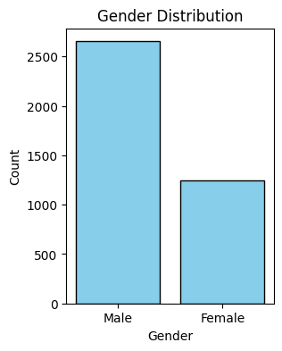

```python
plt.figure(figsize=(3, 4))
plt.bar(gender_counts.index, gender_counts.values,color='skyblue', edgecolor='black')

plt.xlabel('Gender')
plt.ylabel('Count')
plt.title('Gender Distribution')
plt.show()
```

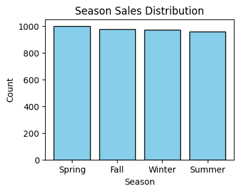

```python
import matplotlib.pyplot as plt

Season_Sales = df['Season'].value_counts()

plt.figure(figsize=(4, 3))
plt.bar(Season_Sales.index, Season_Sales.values, color='skyblue', edgecolor='black')

plt.xlabel('Season')
plt.ylabel('Count')
plt.title('Season Sales Distribution')

plt.show()
```

[output not shown]

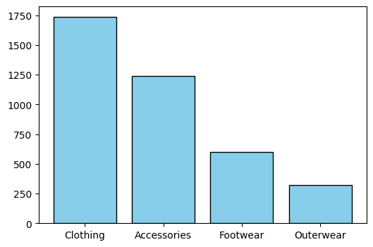

```python
Category=df['Category'].value_counts()
plt.figure(figsize=(6, 4))
plt.bar(Category.index, Category.values, color='skyblue', edgecolor='black')
```

```
Payment Method:
 Payment Method
Credit Card      696
Venmo            653
Cash             648
PayPal           638
Debit Card       633
Bank Transfer    632
Name: count, dtype: int64
```

[figure not shown]

```python
PaymentMethode = df['Payment Method'].value_counts()
print("Payment Method:\n", PaymentMethode)

plt.figure(figsize=(6, 4))

colors = ['#6BA292', '#88B4A1', '#A7C5AF', '#C4D7C4', '#E2E8CE']

plt.bar(PaymentMethode.index, PaymentMethode.values, color=colors[:len(PaymentMethode)], edgecolor='black')

plt.xlabel('Payment Metho', fontsize=12)
plt.ylabel('Count', fontsize=12)
plt.title('Payment Method Distribution', fontsize=14, fontweight='bold')
plt.xticks(rotation=30)
plt.grid(axis='y', linestyle='--', alpha=0.6)

plt.show()
```

```python
print(df.columns)
```

```
Index(['Customer ID', 'Age', 'Gender', 'Item Purchased', 'Category',
       'Purchase Amount (USD)', 'Location', 'Size', 'Color', 'Season',
       'Review Rating', 'Subscription Status', 'Payment Method',
       'Shipping Type', 'Discount Applied', 'Promo Code Used',
       'Previous Purchases', 'Preferred Payment Method',
       'Frequency of Purchases'],
      dtype='object')
```

```python
ItemPurchased=df['Item Purchased'].value_counts(ascending=True).head()
ItemPurchased
```

```
Item Purchased
Jeans       124
Gloves      140
Backpack    143
Boots       144
Sneakers    145
Name: count, dtype: int64
```

[figure not shown]

```python
plt.figure(figsize=(6,4))
plt.bar(ItemPurchased.index, ItemPurchased.values, color="#90AF4C", edgecolor='black')

plt.title('Top Purchased Items', fontsize=16, fontweight='bold')
plt.xlabel('Item', fontsize=12)
plt.ylabel('Number of Purchases', fontsize=12)

plt.xticks(rotation=45, ha='right')
plt.grid(axis='y', linestyle='--', alpha=0.7)
plt.tight_layout()
plt.show()
```

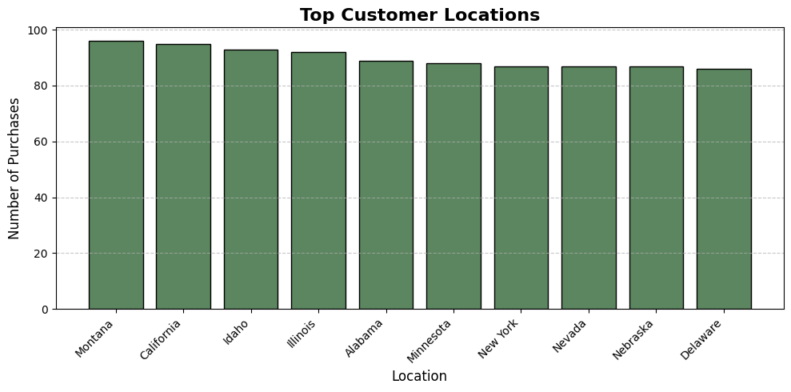

```python
TopLocation = df['Location'].value_counts().head(10)

plt.figure(figsize=(10,5))
plt.bar(TopLocation.index, TopLocation.values, color="#5B865F", edgecolor='black')

plt.title('Top Customer Locations', fontsize=16, fontweight='bold')
plt.xlabel('Location', fontsize=12)
plt.ylabel('Number of Purchases', fontsize=12)

plt.xticks(rotation=45, ha='right')
plt.grid(axis='y', linestyle='--', alpha=0.7)
plt.tight_layout()
plt.show()
```

part5

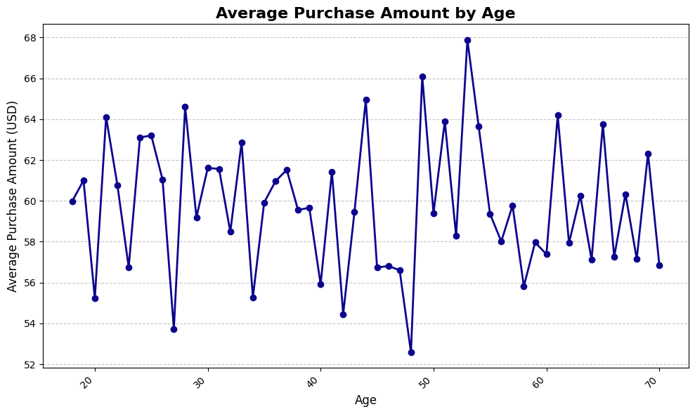

```python
age_mean_sales = df.groupby('Age')['Purchase Amount (USD)'].mean()

plt.figure(figsize=(10,6))
plt.plot(age_mean_sales.index, age_mean_sales.values, color="#0D048E", marker='o', linewidth=2)

plt.title('Average Purchase Amount by Age', fontsize=16, fontweight='bold')
plt.xlabel('Age', fontsize=12)
plt.ylabel('Average Purchase Amount (USD)', fontsize=12)

plt.xticks(rotation=45, ha='right')
plt.grid(axis='y', linestyle='--', alpha=0.7)
plt.tight_layout()
plt.show()
```

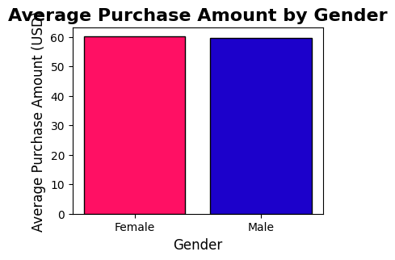

```python
Gender_Sales = df.groupby('Gender')['Purchase Amount (USD)'].mean()

plt.figure(figsize=(4,3))
bars = plt.bar(Gender_Sales.index, Gender_Sales.values, color=["#FF1064", "#1C01CB"], edgecolor='black')

plt.title('Average Purchase Amount by Gender', fontsize=16, fontweight='bold')
plt.xlabel('Gender', fontsize=12)
plt.ylabel('Average Purchase Amount (USD)', fontsize=12)
plt.show()
```

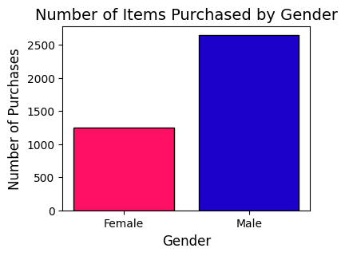

```python
ItemPurchased_Gender = df.groupby('Gender')['Item Purchased'].count()


plt.figure(figsize=(4,3))
bars = plt.bar(ItemPurchased_Gender.index, ItemPurchased_Gender.values,
               color=["#FF1064", "#1C01CB"], edgecolor='black')

plt.title('Number of Items Purchased by Gender', fontsize=14)
plt.xlabel('Gender', fontsize=12)
plt.ylabel('Number of Purchases', fontsize=12)
plt.show()
```

```
Gender
Female    1248
Male      2652
Name: Discount Applied, dtype: int64
```

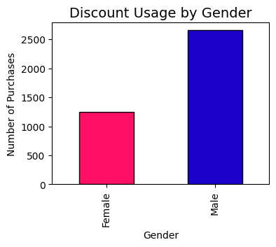

```python
import pandas as pd
import matplotlib.pyplot as plt



discount_Gender = df.groupby('Gender')['Discount Applied'].count()
print(discount_Gender)

discount_Gender.plot(kind='bar',  color=['#FF1064','#1C01CB'], edgecolor='black', figsize=(4,3))
plt.title('Discount Usage by Gender', fontsize=14)
plt.xlabel('Gender')
plt.ylabel('Number of Purchases')

plt.show()
```

```
Discount Applied
No     60.130454
Yes    59.279070
Name: Purchase Amount (USD), dtype: float64
```

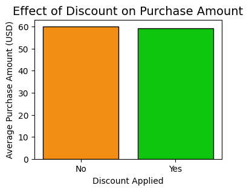

```python
discount_effect = df.groupby('Discount Applied')['Purchase Amount (USD)'].mean()
print(discount_effect)


plt.figure(figsize=(4,3))
bars = plt.bar(discount_effect.index, discount_effect.values,
               color=["#F28E14", "#0FC60F"], edgecolor='black')

plt.title('Effect of Discount on Purchase Amount', fontsize=14)
plt.xlabel('Discount Applied')
plt.ylabel('Average Purchase Amount (USD)')
plt.show()
```

part6

Average Sales amount by gender and discount

```python
df.groupby(['Gender', 'Discount Applied'])['Purchase Amount (USD)'].mean().round(0)
```

```
Gender  Discount Applied
Female  No                  60.0
Male    No                  60.0
        Yes                 59.0
Name: Purchase Amount (USD), dtype: float64
```

```python
# Number of purchases based on location and product category
df.groupby(['Location', 'Category'])['Item Purchased'].count()
```

```
Location   Category
Alabama    Accessories    25
           Clothing       41
           Footwear       15
           Outerwear       8
Alaska     Accessories    26
                          ..
Wisconsin  Outerwear       3
Wyoming    Accessories    23
           Clothing       31
           Footwear       11
           Outerwear       6
Name: Item Purchased, Length: 200, dtype: int64
```

part7

🧩 تحلیل داده‌های رفتار خرید مشتریان 📊 پروژه تحلیل داده (Shopping Trends Analysis)

در این پروژه، داده‌های مربوط به خرید مشتریان بررسی شد تا الگوهای رفتاری، ترجیحات پرداخت و عوامل تأثیرگذار بر میزان خرید شناسایی شوند. هدف اصلی، استخراج بینش‌های قابل‌اجرا (Insights) برای تصمیم‌گیری بهتر در حوزه‌ی بازاریابی و فروش بود.

🧹 مراحل انجام پروژه

1️⃣ Data Cleaning:

حذف مقادیر نادرست و پرت

استانداردسازی متون (مثل اصلاح روش پرداخت و جنسیت)

2️⃣ Univariate Analysis:

بررسی توزیع متغیرهایی مثل سن، جنسیت، فصل خرید و مبلغ خرید

3️⃣ Bivariate Analysis:

تحلیل رابطه بین دو متغیر (مثلاً تأثیر سن بر مبلغ خرید)

بررسی الگوهای خرید بر اساس جنسیت و روش پرداخت

🧰 ابزارها و کتابخانه‌ها (Tools & Libraries)

💬 نکته پایانی

این پروژه بخشی از مسیر من در یادگیری تحلیل داده‌ها (Data Analysis) است. تمرکزم بر کشف الگوهای واقعی در داده و تبدیل آن‌ها به بینش‌های کاربردی است. خوشحال می‌شم نظرتون رو درباره‌ی این تحلیل بدونم 🙌

# DataAnalysis #Python #DataCleaning #EDA #ShoppingTrends #Matplotlib #Pandas